# US distress models revisited

## dummy slide

# Introduction

Hazard models are powerful distress models.

Popular since Shumway (2001).

$$\begin{align*}
y_{it} &\in\{0,1\}\\
g(E(y_{it}|\vec x_{it}, \vec z_t)) &=
\vec\beta^\top\vec x_{it}+ \vec \gamma^\top \vec z_t
\end{align*}$$

$y_{it}$s are binary distress indicator, $\vec x_{it}$s are firm covariates, and $\vec{z}_t$s are macro variables.

E.g., see Chava and Jarrow (2004), Beaver, McNichols, and Rhie (2005), and Campbell and Szilagyi (2008).

## Large time variation

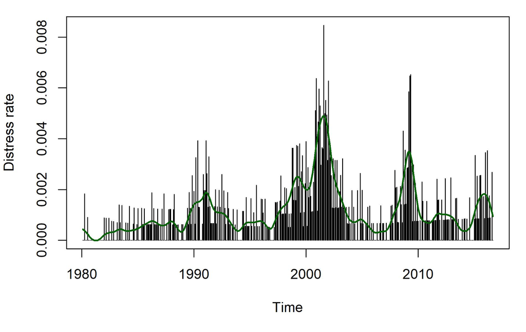

Cannot be caputured by firm specific covariates, $\vec x_{it}$, and macro covariates, $\vec z_t$. Major issue for portfolio risk.

## Frailty models

Extend to include latent effects

$$\begin{align*}
g(E(y_{it}|\vec x_{it}, \vec z_t, \vec u_t, \vec o_{it})) &=
\vec\beta^\top\vec x_{it}+ \vec \gamma^\top \vec z_t
+ \vec u_t^\top \vec o_{it} \\
\vec u_t &\sim p_{\vec \theta}(\vec u_{t-1})
\end{align*}$$

Pioneered by Duffie et al. (2009).

E.g., see Koopman, Lucas, and Schwaab (2011), Azizpour, Giesecke, and Schwenkler (2016), Nickerson and Griffin (2017), and Kwon and Lee (2018).

## Motivation

> Although an OU process is a reasonable starting model for the frailty process, one could allow much richer frailty models. …, however, we have found that even our relatively large data set is too limited to identify much of the time-series properties of frailty. … For the same reason, we have not attempted to identify sector-specific frailty effects.

> Duffie et al. (2009)

# Talk overview

Data set.

Models without frailty.

Models with frailty.

# Data set

Merge CRSP and Compustat.

Merge with Moody’s Analytics Default & Recovery Database.

## Distress events

At risk: have not had a distress, is after resolution date, or 12 months after distress if resolution date is missing.

Events are alternative dispute resolution, conservatorship, cross default, loan forgiven, chapter 7, placed under administration, seized by regulators, deposit freeze, suspension of payments, grace period default, payment moratorium, prepackaged chapter 11, indenture modified, bankruptcy, receivership, missed principal payment, missed principal and interest payments, distressed exchange, chapter 11, and missed interest payment.

Missed interest payment is by far the most common.

Macthing to Compustat is done with CUSIPs, ticker symbols, and company names.

## Compustat data

Use quatlery data and impute yearly data when missing.

Data is lagged with 3 months and carried forward for up to 1 year.

## CRSP

Used to compute idiosyncratic volatility. Standard deviation from 1 year rolling regression of daily stock log return on the log market return. Require 3 months data in window and 1 year initial data.

Used to compute past 1 year excess log return.

Used to compute log relative market size.

Data is lagged with 1 month and carried forward for up to 3 months.

## Distance-to-default

Very good predictor (Bharath and Shumway 2008).

Computed with the so-called KMV method (Vassalou and Xing 2004). Computed with daily stock data, debt data from Compustat, 1 year T-bill rate, and with a rolling 1 year window.

Require 1 year initial data and at-least 3 months of data in each window.

## Final sample

Exclude firms with first digit SIC code 6 or 9. Use compustat `siccd` if avialable. Otherwise use CRSP `sich`.

Final samples has 624,692 firm-months, 4,433 firms and 721 events.

# Models without frailty

Included variables are

- Working capital / total assets
- Retained Earnings / total assets
- Operating income / total assets
- Market value / total liabilities
- Sales / total assets
- Net income / total assets
- Total liabilities / total assets
- Current ratio
- Idiosyncratic volatility
- Log excess return
- Relative log market size

All winsorized at 1% and 99%.

## First model

|  | Df | AIC |
| --- | --- | --- |
| First model | 12 | 7612.93 |
| New denominator | 12 | 7559.93 |
| Add distance-to-default | 13 | 7469.90 |
| Add macro variables | 15 | 7447.24 |
| Simplify model | 11 | 7441.04 |

## Change denominators

|  | Df | AIC |
| --- | --- | --- |
| First model | 12 | 7612.93 |
| New denominator | 12 | 7559.93 |
| Add distance-to-default | 13 | 7469.90 |
| Add macro variables | 15 | 7447.24 |
| Simplify model | 11 | 7441.04 |

Issue with small denominators as in Campbell and Szilagyi (2008). Change denominator to 50%. total assets and 50% market value.

## Add distance-to-default

|  | Df | AIC |
| --- | --- | --- |
| First model | 12 | 7612.93 |
| New denominator | 12 | 7559.93 |
| Add distance-to-default | 13 | 7469.90 |
| Add macro variables | 15 | 7447.24 |
| Simplify model | 11 | 7441.04 |

## Macro variables

|  | Df | AIC |
| --- | --- | --- |
| First model | 12 | 7612.93 |
| New denominator | 12 | 7559.93 |
| Add distance-to-default | 13 | 7469.90 |
| Add macro variables | 15 | 7447.24 |
| Simplify model | 11 | 7441.04 |

Past 1 year market log market return and 1 year T-bill rate.

## Remove terms

|  | Df | AIC |
| --- | --- | --- |
| First model | 12 | 7612.93 |
| New denominator | 12 | 7559.93 |
| Add distance-to-default | 13 | 7469.90 |
| Add macro variables | 15 | 7447.24 |
| Simplify model | 11 | 7441.04 |

## Estimates – Standardized coefficients

|  | Estimate | Z-stat |
| --- | --- | --- |
| Intercept | -8.448 | -17.985 |
| Distance-to-default | -1.929 | -9.034 |
| Log excess return | -0.713 | -18.711 |
| Total liabilities / size | 0.437 | 8.365 |
| T-bill rate | -0.281 | -5.113 |
| Net income / size | -0.110 | -5.650 |
| Relative log market size | -0.107 | -1.702 |
| Current ratio | -0.101 | -1.999 |
| Idiosyncratic volatility | 0.092 | 2.449 |
| Log market return | 0.078 | 2.287 |
| Retained Earnings / size | 0.042 | 1.543 |

## Non-linear effects – Net income to size

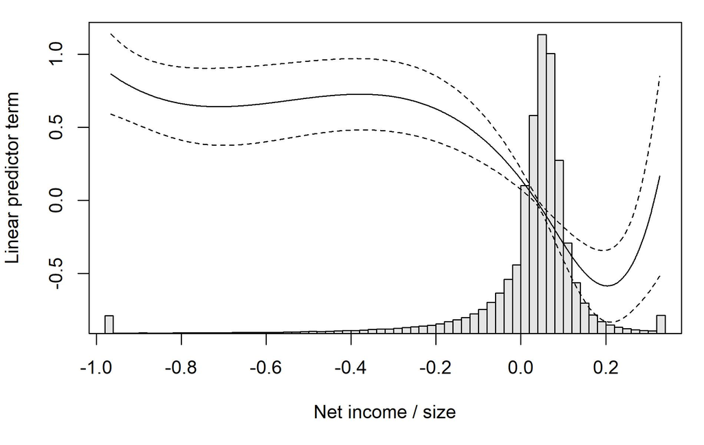

Add cubic regression spline. Dashed lines are 95% confidence intervals of the regression spline.

## Non-linear effects – Idiosyncratic volatility

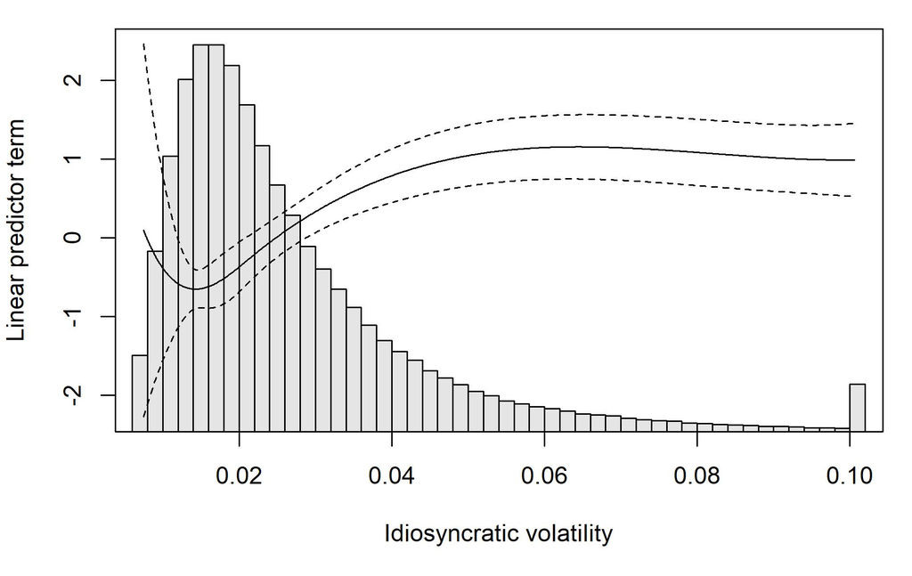

## Significance of terms

|  | AIC | Df | LR-stat | P-value |
| --- | --- | --- | --- | --- |
| Full model | 7377.98 |  |  |  |
| % Relative log market size | 7378.14 | 1 | 2.16 | 0.141196 |
| % Retained Earnings / size | 7378.98 | 1 | 3.00 | 0.083270 |
| % Log market return | 7380.39 | 1 | 4.41 | 0.035750 |
| % Current ratio | 7382.43 | 1 | 6.45 | 0.011094 |
| % Net income / size (spline term) | 7393.20 | 3 | 21.23 | 0.000094 |
| % Idiosyncratic volatility | 7398.73 | 1 | 22.75 | 0.000002 |
| % T-bill rate | 7406.89 | 1 | 30.91 | < 0.000001 |
| % Idiosyncratic volatility (spline term) | 7413.60 | 3 | 41.62 | < 0.000001 |
| % Distance-to-default | 7418.65 | 1 | 42.67 | < 0.000001 |
| % Net income / size | 7423.10 | 1 | 47.12 | < 0.000001 |
| % Total liabilities / size | 7457.40 | 1 | 81.42 | < 0.000001 |
| % Log excess return | 7732.36 | 1 | 356.38 | < 0.000001 |

Rows are models without the given term. The spline terms are orthogonal to the linear term. P-values are based on likelihood ratio test.

## In-sample results

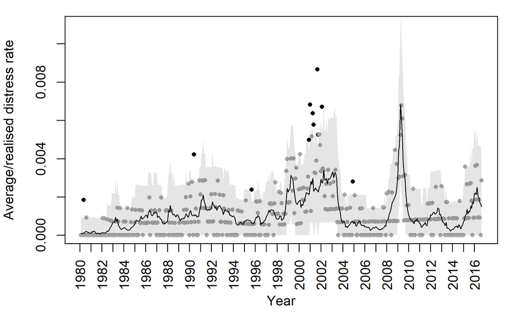

Gray area is pointwise 95% confidence intervals. The line is the predicted distress rate. Dots are realised distress rates. Black dots are not covered by confidence intervals.

## Out-sample results

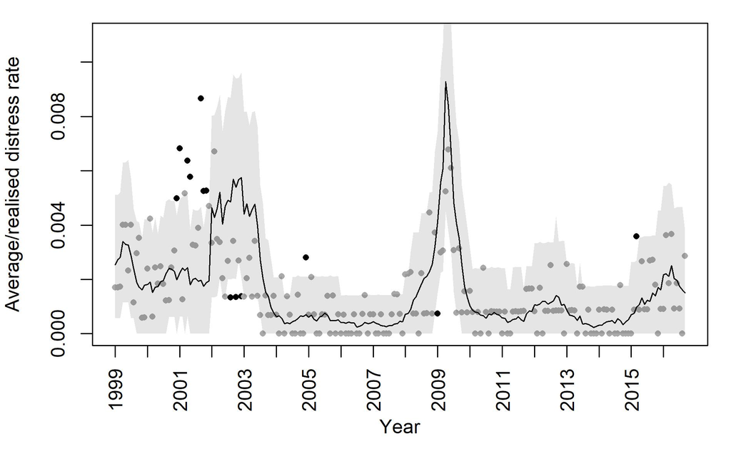

Model is estimated up to the year prior to the forecasting year.

# Models with frailty

Starting point is a time-varying intercept as in Duffie et al. (2009).

$$\begin{align*}
g(E(y_{it}|\vec x_{it}, \vec z_t, \vec u_t, \vec o_{it})) &=
\vec\beta^\top\vec x_{it}+ \vec \gamma^\top \vec z_t
+ \vec u_t \\
u_t &\sim N(\theta u_{t - 1}, \sigma^2)
\end{align*}$$

where $g$ is the inverse complementary-log-log function.

It may be that they actually do everything in continous time and have $\Delta t \rightarrow 0$ in equation (2) of the paper but this does not appear to be the case when you look at Appendix B and C. Moreover, it seems that a poisson process with a log-offset (the continuous version) is used instead of the inverse complementary-log-log function (the discrete version).

## Frailty model

Use an auxiliary particle filter and smoother to perform the estimation with a Monte Carlo E(C)M algorithm. See Gordon, Salmond, and Smith (1993) for early work on particle filters, Pitt and Shephard (1999) for details on auxiliary particle filtering and Fearnhead, Wyncoll, and Tawn (2010) for the smoother I use. See Dempster, Laird, and Rubin (1977) and Meng and Rubin (1993) for respectivly details on the EM and ECM algorithm.

For details so the R package at CRAN.R-project.org/package=dynamichazard.

# References

Azizpour, Shahriar, Kay Giesecke, and Gustavo Schwenkler. 2016. “Exploring the Sources of Default Clustering.”

Beaver, William H., Maureen F. McNichols, and Jung-Wu Rhie. 2005. “Have Financial Statements Become Less Informative? Evidence from the Ability of Financial Ratios to Predict Bankruptcy.” *Review of Accounting Studies* 10 (1): 93–122. doi:10.1007/s11142-004-6341-9.

Bharath, Sreedhar T., and Tyler Shumway. 2008. “Forecasting Default with the Merton Distance to Default Model.” *The Review of Financial Studies* 21 (3): 1339–69. doi:10.1093/rfs/hhn044.

Campbell, Jens, John Y. And Hilscher, and Jan Szilagyi. 2008. “In Search of Distress Risk.” *The Journal of Finance* 63 (6). Blackwell Publishing Inc: 2899–2939. doi:10.1111/j.1540-6261.2008.01416.x.

Chava, Sudheer, and Robert A. Jarrow. 2004. “Bankruptcy Prediction with Industry Effects *.” *Review of Finance* 8 (4): 537–69. doi:10.1093/rof/8.4.537.

Dempster, A. P., N. M. Laird, and D. B. Rubin. 1977. “Maximum Likelihood from Incomplete Data via the Em Algorithm.” *Journal of the Royal Statistical Society. Series B (Methodological)* 39 (1). [Royal Statistical Society, Wiley]: 1–38. http://www.jstor.org/stable/2984875.

Duffie, Darrell, Andreas Eckner, Guillaume Horel, and Leandro Saita. 2009. “Frailty Correlated Default.” *The Journal of Finance* 64 (5). Blackwell Publishing Inc: 2089–2123. doi:10.1111/j.1540-6261.2009.01495.x.

Fearnhead, Paul, David Wyncoll, and Jonathan Tawn. 2010. “A Sequential Smoothing Algorithm with Linear Computational Cost.” *Biometrika* 97 (2). [Oxford University Press, Biometrika Trust]: 447–64. http://www.jstor.org/stable/25734097.

Gordon, N. J., D. J. Salmond, and A. F. M. Smith. 1993. “Novel Approach to Nonlinear/Non-Gaussian Bayesian State Estimation.” *IEE Proceedings F - Radar and Signal Processing* 140 (2): 107–13. doi:10.1049/ip-f-2.1993.0015.

Koopman, Siem Jan, André Lucas, and Bernd Schwaab. 2011. “Modeling Frailty-Correlated Defaults Using Many Macroeconomic Covariates.” *Journal of Econometrics* 162 (2): 312–25. doi:https://doi.org/10.1016/j.jeconom.2011.02.003.

Kwon, Tae Yeon, and Yoonjung Lee. 2018. “Industry Specific Defaults.” *Journal of Empirical Finance* 45: 45–58. doi:https://doi.org/10.1016/j.jempfin.2017.10.002.

Meng, Xiao-Li, and Donald B. Rubin. 1993. “Maximum Likelihood Estimation via the Ecm Algorithm: A General Framework.” *Biometrika* 80 (2). [Oxford University Press, Biometrika Trust]: 267–78. http://www.jstor.org/stable/2337198.

Nickerson, Jordan, and John M. Griffin. 2017. “Debt Correlations in the Wake of the Financial Crisis: What Are Appropriate Default Correlations for Structured Products?” *Journal of Financial Economics* 125 (3): 454–74. doi:https://doi.org/10.1016/j.jfineco.2017.06.011.

Pitt, Michael K., and Neil Shephard. 1999. “Filtering via Simulation: Auxiliary Particle Filters.” *Journal of the American Statistical Association* 94 (446). [American Statistical Association, Taylor & Francis, Ltd.]: 590–99. http://www.jstor.org/stable/2670179.

Shumway, Tyler. 2001. “Forecasting Bankruptcy More Accurately: A Simple Hazard Model.” *The Journal of Business* 74 (1). The University of Chicago Press: 101–24. http://www.jstor.org/stable/10.1086/209665.

Vassalou, Maria, and Yuhang Xing. 2004. “Default Risk in Equity Returns.” *The Journal of Finance* 59 (2). [American Finance Association, Wiley]: 831–68. http://www.jstor.org/stable/3694915.